# Mini-Project 2

Thao Phan & Asmita Gautam

March 24, 2017

```r
#loading the data
library(tidyverse)
load("house_elections.rda")
load("candidates.rda")
load("committees.rda")
load("contributions.rda")
```

### Background for our Candidates dataset analysis

We first used outside data to find the top 10 states with the most electoral votes because we thought that since they have the highest number of votes that they’d be a big influence on elections. We chose to focus on the Democratic and Republican parties because they’re the most popular and most likely to win. We hypothesized that if a state is known to be more Democratic, then there’d be more Democrats running in that state than Republican candidates.

```r
#function for making ggplot
cand_ggPlot_func <- function( data, title){
  ggplot( data, aes(x = cand_office_state, y = n, fill = cand_party_affiliation, width = .5)) +
  geom_bar(stat = "identity", position = position_dodge()) +
  theme_minimal() +
  ggtitle(title) +
  scale_fill_manual(values = alpha(c("steelblue2", "indianred2"))) +
  labs( fill = "Candidate Party Affiliation" ) +
  labs(x = "Candidate's Office State") +
  labs(y = "# of Candidates in Each Party")
}
```

```r
#function for candidates dataset
candidatesFunc <- function( party1, party2, s1, s2, s3, s4, s5, s6, s7, s8, s9, s10 ) {
  candidates %>%
    filter( cand_party_affiliation == c( party1, party2 ) ) %>%
    filter( cand_office_state == c( s1, s2, s3, s4, s5, s6, s7, s8, s9, s10 ) ) %>%
    group_by( cand_office_state, cand_party_affiliation ) %>%
    summarise( n = n() )
}
```

```r
# Below we use the candidates function
# States: CA, FL, GA, IL, MI, NC, NJ, NY, OH, PA, TX
top_10 <- candidatesFunc( party1 = "DEM", party2 = "REP", s1 = "CA", s2 = "FL", s3 = "GA", s4 = "IL", s5 = "MI", s6 = "NC", s7  = "NJ", s8 = "NY", s9 = "OH", s10 = "PA" )
```

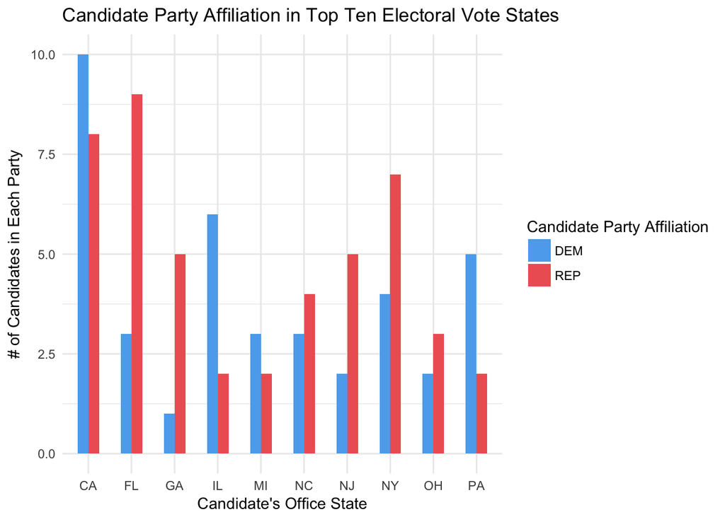

```r
cand_ggPlot_func( top_10, "Candidate Party Affiliation in Top Ten Electoral Vote States")
```

### Analysis of ggplot

In our ggplot for the top 10 electoral vote states, we thought that since California and Pennsylvania are known to be more Democratic than Republican, there would be more Democratic candidates. Our hypothesis turned out to be correct with both states having more Democratic candidates than Republicans. What’s interesting is that Illinois, which we thought to be more Republican but has more Democratic candidates. Our interpretation was that due to strong support for one of the Republican candidates in the state, many people choose not to run, whereas Democratic candidates take their chances.

```r
# Candidates in North Eastern States
# States: RI MA ME NH NJ NY PA CT VT
north_cand <- candidatesFunc( party1 = "DEM", party2 = "REP", s1 = "RI", s2 = "MA", s3 = "ME", s4 = "PA", s5 = "NJ", s6 = "NY", s7  = "NH", s8 = "CT", s9 = "VT", s10 = NA )
```

### Background for plot 2

In our data below, we analyzed the candidate’s party affiliation of the north eastern states. In an article about the political affiliations of north eastern states written by political writer Lydia Saad, she stated that the east has a high concentration of heavily Democratic states. She thinks that this is due to the waning popularity of Republican President George W. Bush in 2008, the economic crisis that erupted that year, and the growing popularity and appeal of Barach Obama late in the presidential campaign that led to Democrats having more support. Anyway, we analyzed the northeastern states to see if they popularity was true.

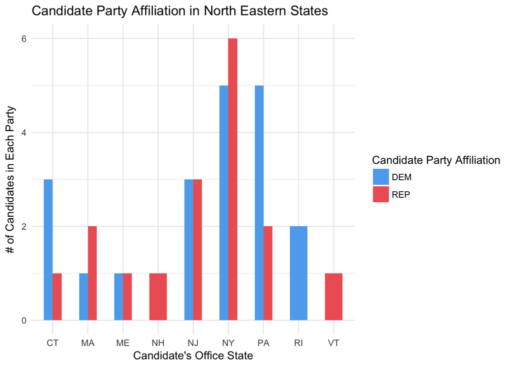

```r
cand_ggPlot_func( north_cand, "Candidate Party Affiliation in North Eastern States")
```

### Analysis

In our findings, we saw that while there definitely were candidates running for the Democratic party, for some states (MA) and (NY), they had more Republican candidates running. NH and VT apparently had no Democratic candidates at all which seems inaccurate. However, we will chalk this up to the errors that could potentially be on our part.

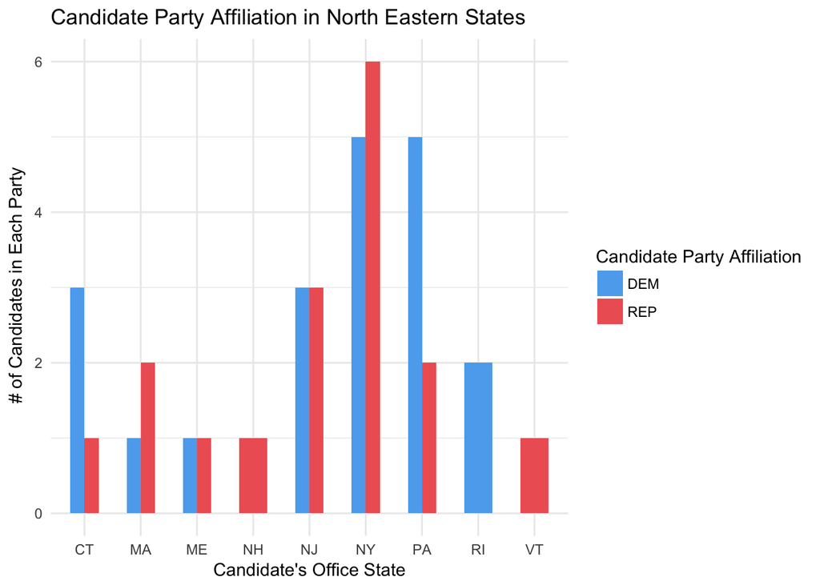

```r
ggplot( north_cand, aes(x = cand_office_state, y = n, fill = cand_party_affiliation, width = .5)) +
  geom_bar(stat = "identity", position = position_dodge()) +
  theme_minimal() +
  ggtitle("Candidate Party Affiliation in North Eastern States") +
  scale_fill_manual(values = alpha(c("steelblue2", "indianred2"))) +
  labs( fill = "Candidate Party Affiliation") +
  labs(x = "Candidate's Office State") +
  labs(y = " # of Candidates in Each Party")
```

```r
# FUNCTION 2: "committeesFunc"
# lets you compare any two parties in any 10 eleven states in committees data set
committeesFunc <- function( party1, party2, s1, s2, s3, s4, s5, s6, s7, s8, s9, s10 ) {
  committees %>%
    filter( cmte_party_affiliation == c( party1, party2 ) ) %>%
    filter( cmte_state == c( s1, s2, s3, s4, s5, s6, s7, s8, s9, s10 ) ) %>%
    group_by( cmte_state, cmte_party_affiliation ) %>%
    summarise( n = n() )
}
```

```r
# Committee Party affiliation in Top Ten Electoral Vote States
# States: CA, FL, GA, IL, MI, NC, NJ, NY, OH, PA
top_10_cmte <- committeesFunc( party1 = "DEM", party2 = "REP", s1 = "CA", s2 = "FL", s3 = "GA", s4 = "IL", s5 = "MI", s6 = "NC", s7  = "NJ", s8 = "NY", s9 = "OH", s10 = "PA")
top_10_cmte
```

```
## Source: local data frame [18 x 3]
## Groups: cmte_state [?]
##
##    cmte_state cmte_party_affiliation     n
##         <chr>                  <chr> <int>
## 1          CA                    DEM    11
## 2          CA                    REP    14
## 3          FL                    DEM     5
## 4          FL                    REP     7
## 5          GA                    DEM     1
## 6          GA                    REP     3
## 7          IL                    DEM     5
## 8          IL                    REP     4
## 9          MI                    DEM     6
## 10         MI                    REP     4
## 11         NC                    REP     4
## 12         NJ                    DEM     3
## 13         NJ                    REP     3
## 14         NY                    DEM     5
## 15         NY                    REP     2
## 16         OH                    REP     4
## 17         PA                    DEM     3
## 18         PA                    REP     8
```

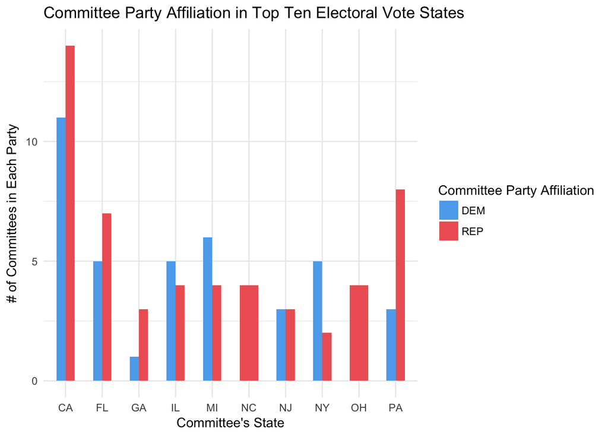

```r
ggplot( top_10_cmte, aes(x = cmte_state, y = n, fill = cmte_party_affiliation, width = .5) ) +
  geom_bar(stat = "identity", position = position_dodge()) +
  theme_minimal() +
  ggtitle("Committee Party Affiliation in Top Ten Electoral Vote States") +
  scale_fill_manual(values = alpha(c("steelblue2", "indianred2"))) +
  labs( fill = "Committee Party Affiliation") +
  labs(x = "Committee's State") +
  labs(y = "# of Committees in Each Party")
```

```r
# Committees Party Affiliation in Northeastern States
# States: AZ, CA, CO, ID, MO, NM, NV, OR, UT, WA, WY
north_com <- committeesFunc( party1 = "DEM", party2 = "REP", s1 = "CT", s2 = "MA", s3 = "ME", s4 = "NH", s5 = "NJ", s6 = "NY", s7  = "PA", s8 = "RI", s9 = "VT", s10 = "0"  )
```

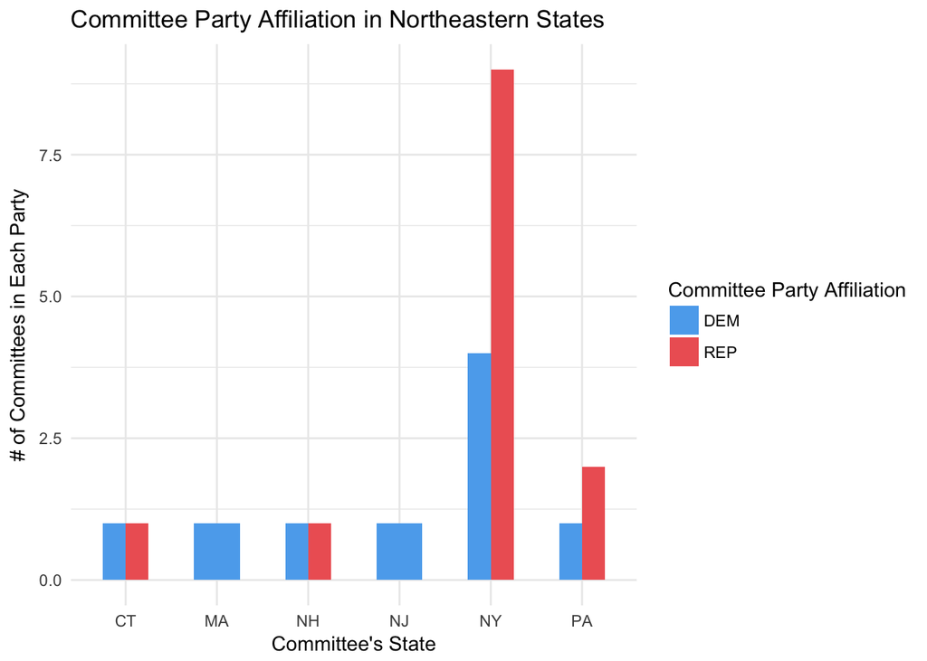

```r
ggplot( north_com, aes(x = cmte_state, y = n, fill = cmte_party_affiliation, width = .5) ) +
  geom_bar(stat = "identity", position = position_dodge()) +
  theme_minimal() +
  ggtitle("Committee Party Affiliation in Northeastern States") +
  scale_fill_manual(values = alpha(c("steelblue2", "indianred2"))) +
  labs( fill = "Committee Party Affiliation") +
  labs(x = "Committee's State") +
  labs(y = "# of Committees in Each Party")
```

```r
# BELOW IS ALL THE CODE WITHOUT THE FUNCTIONS

party_affiliation <- house_elections %>%
  filter( party == c("D", "R") )%>%
  filter( state == c("CA", "FL", "GA", "IL", "MI", "NC", "NJ", "NY", "OH", "PA", "TX")) %>%
  group_by( party, state ) %>%
  summarise( n = n() )
```

### Analysis

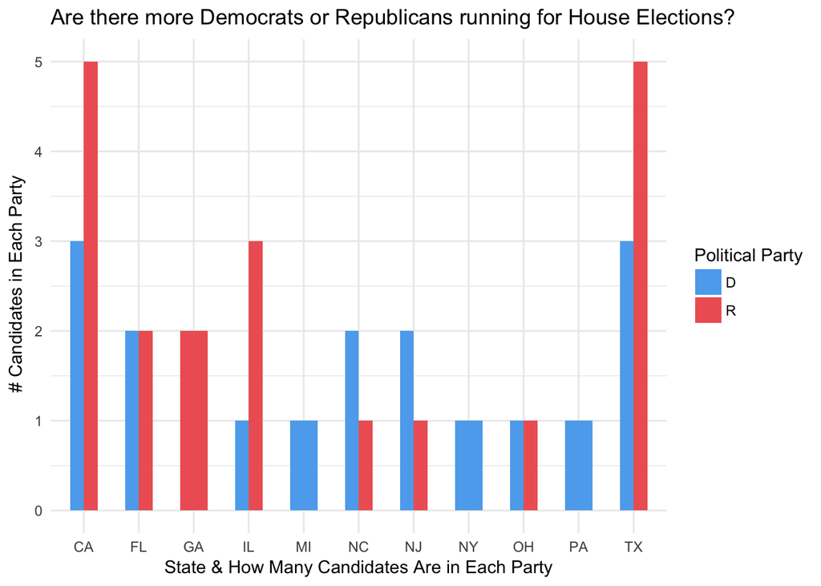

```r
ggplot(party_affiliation, aes(x = state, y = n, fill = party, width = .5)) +
  geom_bar(stat = "identity", position = position_dodge()) +
  theme_minimal() +
  ggtitle("Are there more Democrats or Republicans running for House Elections?") +
  scale_fill_manual(values = alpha(c("steelblue2", "indianred2"))) +
  labs( fill = "Political Party") +
  labs(x = "State & How Many Candidates Are in Each Party") +
  labs(y = " # Candidates in Each Party")
```

### Background for our Contributions dataset analysis

We wanted to see if the states with more committees in our “Committee Party Affiliation in Top Ten Electoral Vote States” graph also had more transactions and contributions. So we merged the two datasets so that we could only look at the contributions for committees in our Committee graph to keep the data consistent and parallel. Our hypothesis was that if the state has more committees they will have more transactions and contributions.

```r
# JOINED DATA
joined_data <- committees %>%
   inner_join(contributions, by = "cmte_id")
```

```r
contrib_data <- joined_data %>%
  filter( cmte_party_affiliation == c("DEM", "REP") )%>%
  filter( cmte_state == c("CA", "FL", "GA", "IL", "MI", "NC", "NJ", "NY", "OH", "PA")) %>%
  group_by( cmte_state, cmte_party_affiliation ) %>%
  summarise( n = sum(transaction_amt) )
```

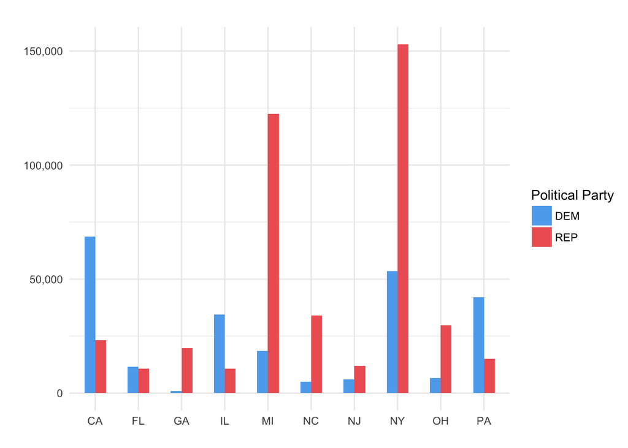

```r
p <- ggplot(contrib_data, aes(x = cmte_state, y = n, fill = cmte_party_affiliation, width = .5)) +
  geom_bar(stat = "identity", position = position_dodge()) +
  theme_minimal() +
  ggtitle("") +
  scale_fill_manual(values = alpha(c("steelblue2", "indianred2"))) +
  labs( fill = "Political Party") +
  labs(x = "") +
  labs(y = "")
require(scales)
p + scale_y_continuous(labels = comma)
```

# Analysis of ggplot

Our hypothesis seems incorrect. It seems like transactions are influenced by where there are more businesses and cities. For example, New York has an average number of committees but the transactions are a huge outlier. Our immediate thought was that Trump Tower is in New York! We did not know much about Michigan to guess why it is an outlier too.